# Simpson Paradox

Besides Regression Fallacy, or Regression to the Mean, a common misconseption that must be adressed when one is dealing with linear regression is the Simpson Paradox.

When the Simpson’s Paradox Happens, it means that the sign of the correlation for the entire population flips when compared to the stratified sample.

Here we will look at the 1973 Admission data from UC Berkeley:

Data:

```r
library(dslabs)
library(tidyverse)
data("admissions")
head(admissions)
```

|  | major | gender | admitted | applicants |
| --- | --- | --- | --- | --- |
| 1 | A | men | 62 | 825 |
| 2 | B | men | 63 | 560 |
| 3 | C | men | 37 | 325 |
| 4 | D | men | 33 | 417 |
| 5 | E | men | 28 | 191 |
| 6 | F | men | 6 | 373 |

At a first impression, one can see that the percentage admissions for men and women differ signifcantly for the entire population:

```r
admissions%>%
  group_by(gender)%>%
  summarise(percentage = round( sum(admitted*applicants)/sum(applicants),1))
```

| gender | percentage |
| --- | --- |
| men | 44.5 |
| women | 30.3 |

And A Chi-squared test for statistical significance rejects the null hypothesis:

```r
library(broom)
admissions%>%
  group_by(gender)%>%
  summarise(total_admitted = round(sum(admitted/100*applicants)), not_admitted = sum(applicants)-sum(total_admitted))%>%
  select((-gender))%>%
  do(tidy(chisq.test(.)))
```

| statistic | p.value | parameter | method |
| --- | --- | --- | --- |
| 91.6096 | 1.055797e-21 | 1 | Pearson's Chi-squared test with Yates' continuity correction |

Investigation of the data:

```r
admissions%>%
  select(major, gender, admitted)%>%
  spread(gender, admitted)%>%
  mutate(women_minus_men = women - men)
```

| major | men | women | women_minus_men |
| --- | --- | --- | --- |
| A | 62 | 82 | 20 |
| B | 63 | 68 | 5 |
| C | 37 | 34 | -3 |
| D | 33 | 35 | 2 |
| E | 28 | 24 | -4 |
| F | 6 | 7 | 1 |

Stratifying for the majors, there seems to not be significant difference between men and women. And a reason for the population bias might be due to major selectivity.

checking the percentage of women applicants by major selectivity:

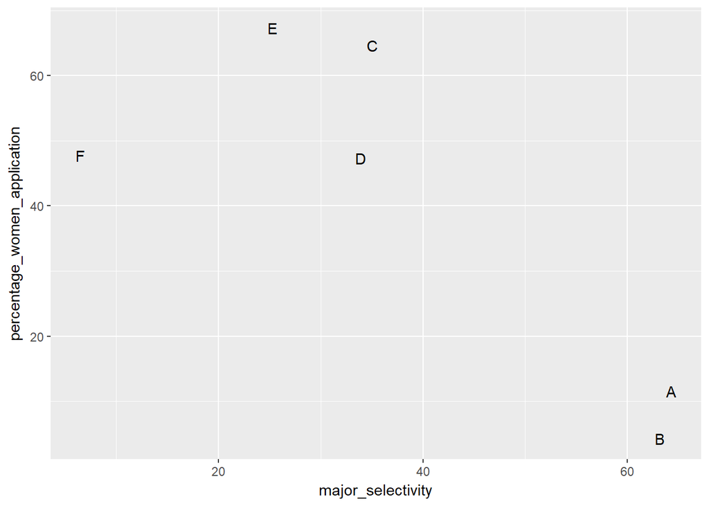

```r
admissions%>%
  group_by(major)%>%
  summarise(major_selectivity = sum(admitted*applicants)/sum(applicants), percentage_women_application = sum(applicants*(gender == "women"))/sum(applicants)*100)%>%
  ggplot(aes(major_selectivity, percentage_women_application))+geom_text(aes(label = major))
```

As we can see from the plot, women tend to apply to more selective majors, while men are more in less selective majors.

-> Gender and major selectivety are confounders

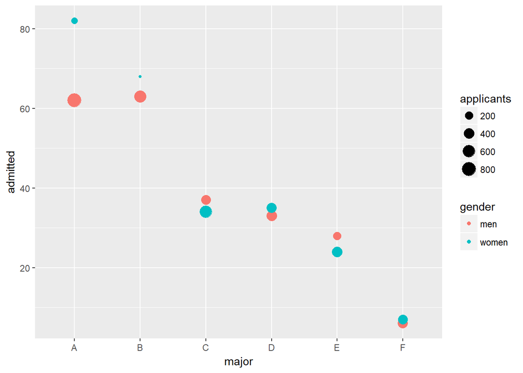

```r
admissions%>%
  ggplot(aes(major, admitted, col = gender, size = applicants))+geom_point()
```

Here we have stratified the population by major and gender, and we can see that the admissions rate is not much different for each gender.